# Using ‘nhstplot’

Nils Myszkowski

2025-11-23

`nhstplot` is a fairly simple package to use. This vignette is intended to explain the basics (plotting using the defaults), before showing how to use the options.

# The basics

After installing the library with `install.packages("nhstplot")` you need to load the library:

```r
library(nhstplot)
```

`nhstplot` is composed of 4 functions, one for each major NHST test “family” :

- $\chi^2$ tests (with the `plotchisqtest` function)
- $F$ tests (with the `plotftest` function)
- $t$ tests (with the `plotttest` function)
- $z$ tests (with the `plotztest` function)

Let’s see how to use each one without changing the graphical options.

## $\chi^2$ tests

The `plotchisqtest` function only requires 2 arguments : The first one is the $\chi^2$ value (parameter : `chisq`), and the second one is the degrees of freedom (parameter `df`).

Here’s an example with respectively 8 and 4.

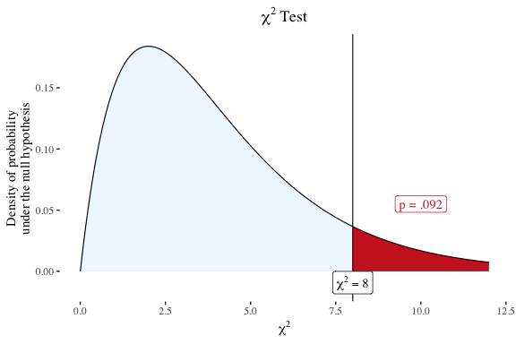

```r
plotchisqtest(chisq = 8, df = 4)
```

Note that the same is achieved with `plotchisqtest(8,4)`.

You can also use the function by passing an object created by `chisq.test()`…

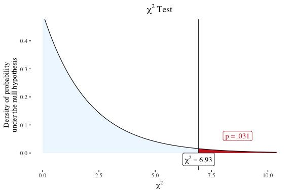

```r
test <- chisq.test(c(A = 37, B = 18, C = 25))
plotchisqtest(test)
```

…or a model comparison from the `anova()` function.

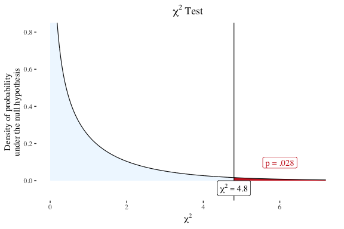

```r
set.seed(1)
y <- rbinom(10, 1, .4) ; x <- 2*y + rnorm(10)
fit1 <- glm(y ~ 1, family = binomial)
fit2 <- glm(y ~ x, family = binomial)
comp <- anova(fit1, fit2, test = "Chisq")
plotchisqtest(comp)
```

You can simply pass the glm object directly. The function will compute a likelihood ratio $\chi^2$ test using the difference between the null and residual deviance:

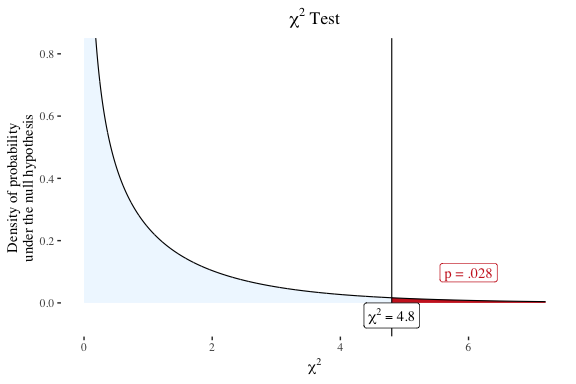

```r
mod <- glm(y ~ x, family = binomial)
plotchisqtest(mod)
```

## $F$ tests

The `plotftest` function only requires 3 arguments : The first one is the $F$ value (parameter : `f`), and the second and third ones are respectively the degrees of freedom of the numerator (parameter `dfnum`) and the denominator (parameter `dfdenom`).

Here’s an example with respectively 4, 3 and 5.

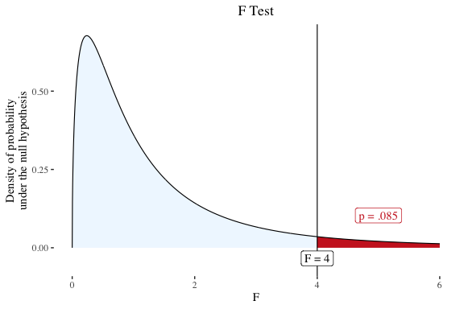

```r
plotftest(f = 4, dfnum = 3, dfdenom = 5)
```

Note that the same is achieved with `plotftest(4,3,5)`.

You can also use the function by passing an object created by `lm()`…

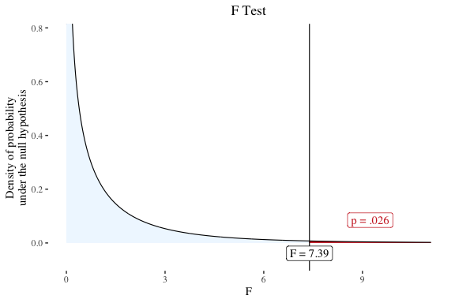

```r
x <- rnorm(10) ; y <- x + rnorm(10)
fit <- lm(y ~ x)
plotftest(fit)
```

…or by passing an F-change test computed with the `anova()` function:

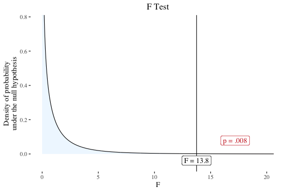

```r
set.seed(1)
x <- rnorm(10) ; y <- x + rnorm(10)
fit1 <- lm(y ~ x)
fit2 <- lm(y ~ poly(x, 2))
comp <- anova(fit1, fit2)
plotftest(comp)
```

## $t$ tests

The `plotttest` function only requires 2 arguments : The first one is the $t$ value (parameter : `t`), and the second one is the degrees of freedom of the numerator (argument `df`).

Here’s an example with respectively 2 and 10.

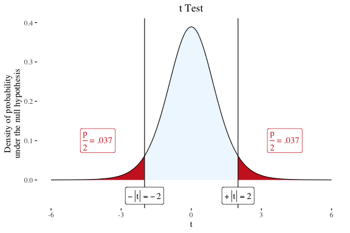

```r
plotttest(t = 2, df = 10)
```

Note that the same is achieved with `plotttest(2,10)`.

By default, the `plotttest` function plots a two-tailed test. However, a one-tailed test can be plotted by adding the argument `tails = "one"`:

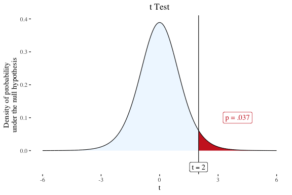

```r
plotttest(2, 10, tails = "one")
```

The left or right tail is automatically selected using the sign of provided $t$:

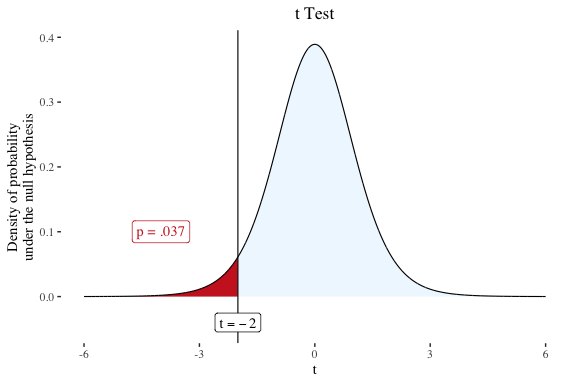

```r
plotttest(-2, 10, tails = "one")
```

You can also use the function by passing an object created by `t.test()`…

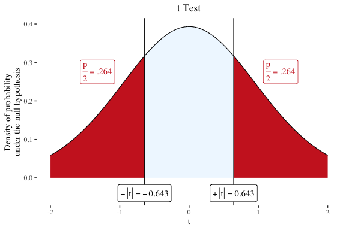

```r
test <- t.test(rnorm(10), rnorm(10))
plotttest(test)
```

…or `cor.test()`.

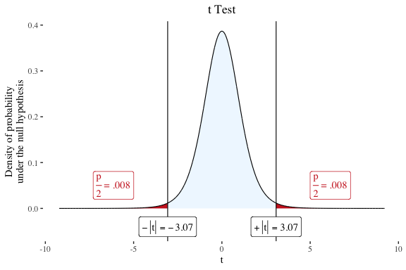

```r
test <- cor.test(rnorm(10), rnorm(10))
plotttest(test)
```

## $z$ tests

The `plotztest` function only requires 1 argument : The $z$ value (parameter `z`).

Here’s an example with a $z$ value of 2.

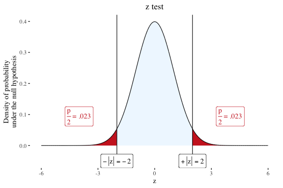

```r
plotztest(z = 2)
```

Note that the same is achieved with `plozttest(2)`.

By default, the `plotztest` function plots a two-tailed test. However, a one-tailed test can be plotted by adding the argument `tails = "one"`:

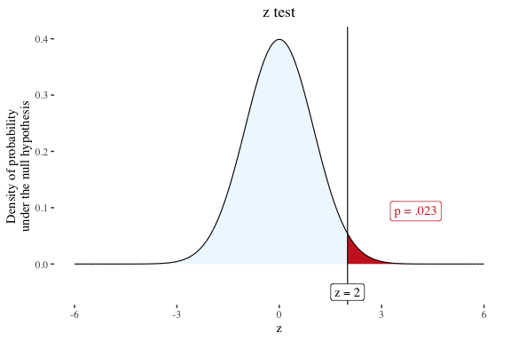

```r
plotztest(2, tails = "one")
```

The left or right tail is automatically selected using the sign of provided $t$:

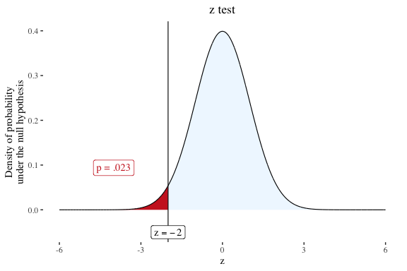

```r
plotztest(-2, tails = "one")
```

# Customizing the output

## Blanking the plot

NHST is a process that isn’t straightforward to explain or understand. Before looking at the $p$ value itself, it starts with stating a null hypothesis. As a consequence, it can be helpful to provide a “step-by-step” explanation of process that may require to plot the density probability function before adding the cutline and p-value.

Hopefully, all the functions in `nhstplot` can do that very simply by passing the argument `blank = TRUE`.

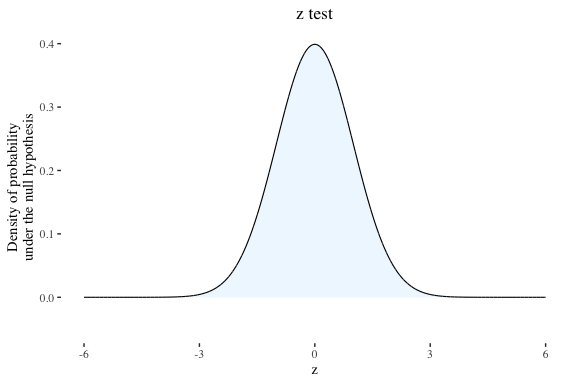

```r
plotztest(-2, blank = TRUE)
```

In reality, when `blank = TRUE`, every thing is plotted the same way as with `blank = FALSE` (default), but some objects are simply make transparent. This means that the two plots are scaled exactly the same way, which can be useful to plot one version after another, for example in slides of a presentation or in an animated gif.

## Changing the x-axis limits

The argument `xmax` can be used to manually provide a maximum for the x-axis. For symmetrical distributions ($t$ and $z$), the minimum is set automatically, so only one value (the maximum) should be provided.

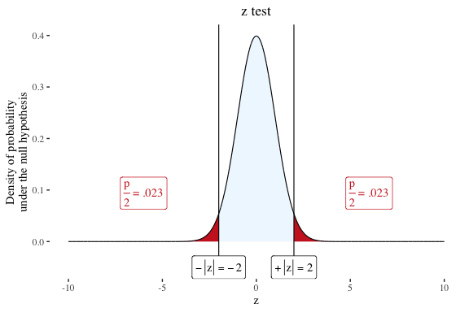

```r
plotztest(2, xmax = 10)
```

## Color themes

For all 4 functions, the default theme is light blue and red (like seen above). But other themes are available with the `theme`parameter, as shown below.

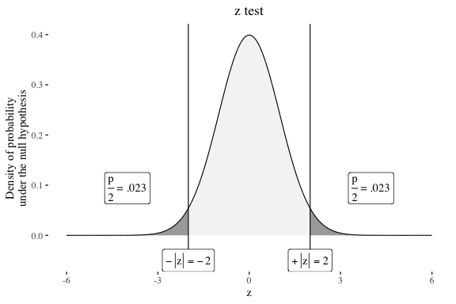

```r
plotztest(2, theme = "blackandwhite")
```

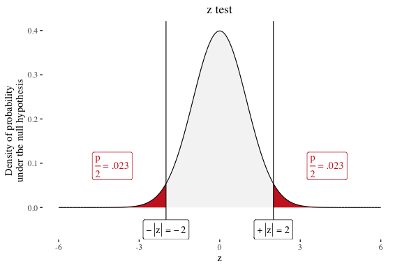

```r
plotztest(2, theme = "whiteandred")
```

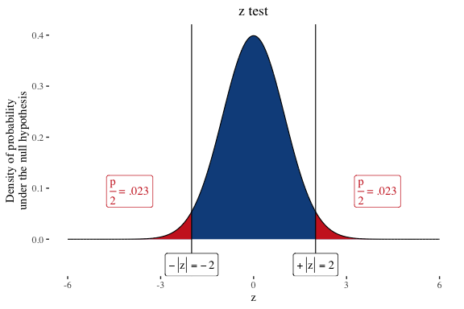

```r
plotztest(2, theme = "blueandred")
```

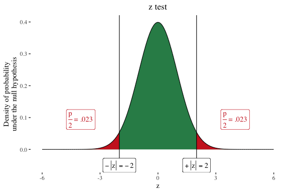

```r
plotztest(2, theme = "greenandred")
```

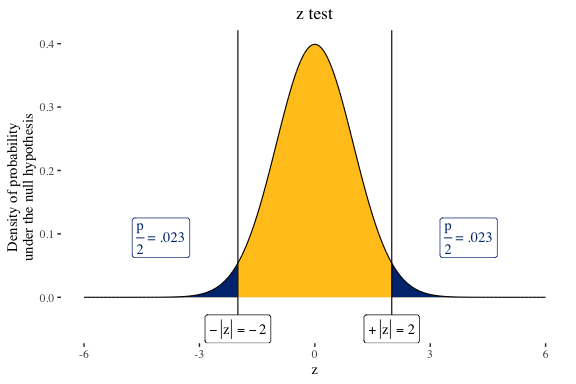

```r
plotztest(2, theme = "goldandblue")
```

## Custom colors

A first important note : The `theme`argument supersedes any custom colors you may use, so don’t provide anything (or `default`) to the `theme` parameter if you want to use custom colors.

- $\chi^2$ and $f$ : The parameters `colorleft`, `colorleftcurve`, `colorright` and `colorrightcurve` control the curve and areas under the curve colors in the `plotchisqtest` and `plotftest` functions. Additionnally, `colorplabel` and `colorcutline` control the colors of the p value label and of the cut line. For example:

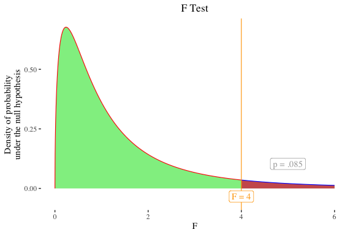

```r
plotftest(4, 3, 5, colorleft = "lightgreen", colorleftcurve = "red", colorright = "indianred", colorrightcurve = "blue", colorplabel = "darkgrey", colorcut = "#FFA500")
```

- $t$ and $z$ :The parameters `colormiddle`, `colormiddlecurve`, `colorsides` and `colorsidescurve` control the curve and areas under the curve colors in the `plotttest` and `plotztest` functions. Additionnally, `colorplabel` (defaults to the same and `colorcutline` control the colors of the p value label and of the cut line. For example:

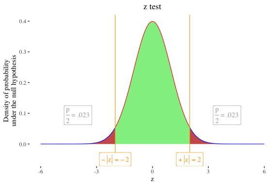

```r
plotztest(2, colormiddle = "lightgreen", colormiddlecurve = "red", colorsides = "indianred", colorsidescurve = "blue", colorplabel = "darkgrey", colorcut = "#FFA500")
```

## Custom fonts

The font family of all the text in the graph can be changed using the `fontfamily` argument (you can for example use `mono`, `Palatino`, `Helvetica` or `sans`. The default is `serif`.

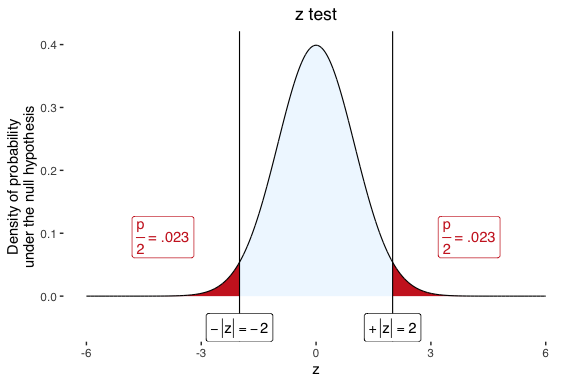

```r
plotztest(2, fontfamily = "Helvetica")
```

- Note that the package `extrafonts` can be used to provide your own fonts (e.g. to match your slides font), and appears to work well with `nhstplot`. Fonts loaded through `extrafonts` can be called in the `fontfamily` argument in the `nhstplot` functions (e.g., `plotztest(2, fontfamily = "Roboto")`).

## Line size

The `cutlinesize`and the `curvelinesize` control the size of the line sizes. By default, the `cutlinesize`is the same as the `curvelinesize`.

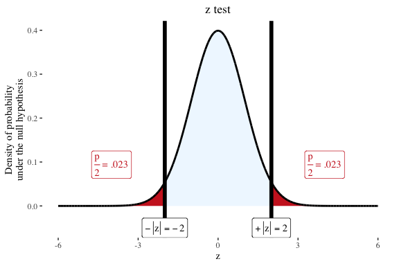

```r
plotztest(2, cutlinesize = 2, curvelinesize = 1)
```

## Digits

The number of significant digits can be modified in all functions using `signifdigitschisq` / `signifdigitsf` / `signifdigitst` / `signifdigitsz` for the test statistic. The default is `3` for all.

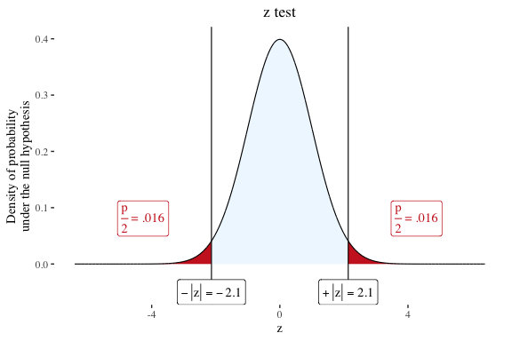

```r
plotztest(2.134553, signifdigitsz = 2)
```

## Changing the $p$ value position

The position of the $p$ value can be changed using the `p_value_position` argument and providing a vector of coordinates. The absolute value is used and the sign is changed depending on whether a one-tailed test is plotted or not (and which tail it is).

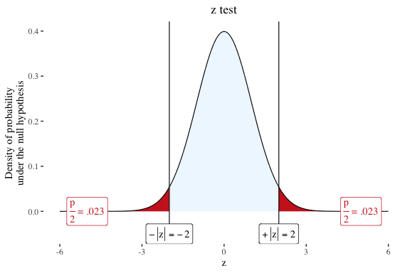

```r
plotztest(2, p_value_position = c(5, 0))
```